# Tutorial 02 - Linear Regression

Olivia Fan

05 October, 2022

## Topics

- Use simple linear regression to describe the relationship between a quantitative predictor and quantitative response variable.
- Estimate the slope and intercept of the regression line using the least squares method.
- Interpret the slope and intercept of the regression line.

## 1. Libraries

The `library()` function is used to access functionality that is provided by R packages, but is not included in base R. `install.packages()` can be used to install new packages. Run this command from the console.

```r
# install.packages("ggplot2")
```

First, load the package `ggplot2` that will be used throughout the tutorial for data visualizations.

```r
library(ggplot2)
```

## 2. Exploratory Data Analysis

This tutorial will be using the `nhanes` dataset where the variables are described in the file `nhanes-codebook.txt`. Load this data with the `load` function and specify the rda data file.

```r
load(file='nhanes1518.rda')
```

The functions `head()` and `names()` can be used to explore the data.

```r
head(nhanes1518)
```

```
## # A tibble: 6 × 52
##    SEQN WTINT2YR WTMEC…¹ RIDST…² RIAGE…³ RIDAG…⁴ INDFM…⁵ RIDRE…⁶ DMDED…⁷ DMDED…⁸
##   <int>    <dbl>   <dbl>   <int>   <int>   <int>   <dbl>   <int>   <int>   <int>
## 1 83732  134671. 135630.       2       1      62    4.39       3       5      NA
## 2 83733   24329.  25282.       2       1      53    1.32       3       3      NA
## 3 83734   12400.  12576.       2       1      78    1.51       3       3      NA
## 4 83735  102718. 102079.       2       2      56    5          3       5      NA
## 5 83736   17628.  18235.       2       2      42    1.23       4       4      NA
## 6 83737   11252.  10879.       2       2      72    2.82       1       2      NA
## # … with 42 more variables: INDHHIN2 <int>, BMXBMI <dbl>, BMXWAIST <dbl>,
## #   BMXWT <dbl>, BMXHT <dbl>, URXUCR <dbl>, WTSB2YR <dbl>, URXCNP <dbl>,
## #   URDCNPLC <int>, URXCOP <dbl>, URDCOPLC <int>, URXECP <dbl>, URDECPLC <int>,
## #   URXHIBP <dbl>, URDHIBLC <int>, URXMBP <dbl>, URDMBPLC <int>, URXMC1 <dbl>,
## #   URDMC1LC <int>, URXMCOH <dbl>, URDMCOLC <int>, URXMEP <dbl>,
## #   URDMEPLC <int>, URXMHBP <dbl>, URDMHBLC <int>, URXMHH <dbl>,
## #   URDMHHLC <int>, URXMHNC <dbl>, URDMCHLC <int>, URXMHP <dbl>, …
```

```r
names(nhanes1518)
```

```
##  [1] "SEQN"     "WTINT2YR" "WTMEC2YR" "RIDSTATR" "RIAGENDR" "RIDAGEYR"
##  [7] "INDFMPIR" "RIDRETH1" "DMDEDUC2" "DMDEDUC3" "INDHHIN2" "BMXBMI"
## [13] "BMXWAIST" "BMXWT"    "BMXHT"    "URXUCR"   "WTSB2YR"  "URXCNP"
## [19] "URDCNPLC" "URXCOP"   "URDCOPLC" "URXECP"   "URDECPLC" "URXHIBP"
## [25] "URDHIBLC" "URXMBP"   "URDMBPLC" "URXMC1"   "URDMC1LC" "URXMCOH"
## [31] "URDMCOLC" "URXMEP"   "URDMEPLC" "URXMHBP"  "URDMHBLC" "URXMHH"
## [37] "URDMHHLC" "URXMHNC"  "URDMCHLC" "URXMHP"   "URDMHPLC" "URXMIB"
## [43] "URDMIBLC" "URXMNP"   "URDMNPLC" "URXMOH"   "URDMOHLC" "URXMZP"
## [49] "URDMZPLC" "WTINT4YR" "WTMEC4YR" "WTSB4YR"
```

We will first explore the dataset by doing exploratory data analysts on the predictor variable `BMXWAIST`:

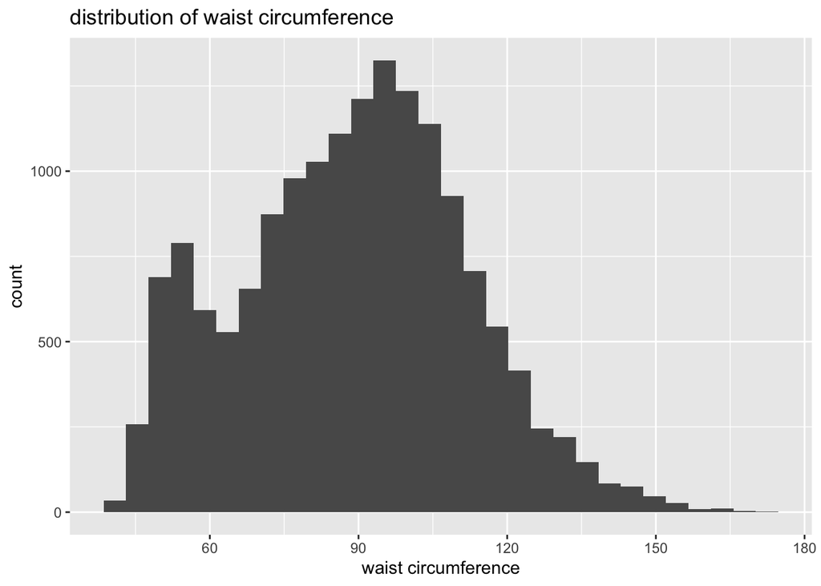

```r
# Basic histogram
ggplot(nhanes1518, aes(x=BMXWAIST)) + geom_histogram()+labs(x = "waist circumference", title = "distribution of waist circumference")
```

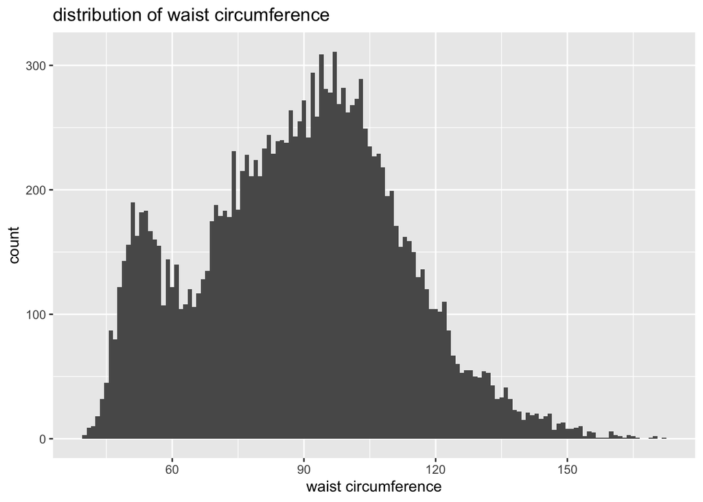

```r
# Change the width of bins
ggplot(nhanes1518, aes(x=BMXWAIST)) +
  geom_histogram(binwidth=1)+labs(x = "waist circumference", title = "distribution of waist circumference")
```

```r
# Change colors
p<-ggplot(nhanes1518, aes(x=BMXWAIST)) +
  geom_histogram(color="black", fill="white")+labs(x = "waist circumference", title = "distribution of waist circumference")
```

We can also add the mean line, as well as overlay with transparent density plot. The value of alpha controls the level of transparency:

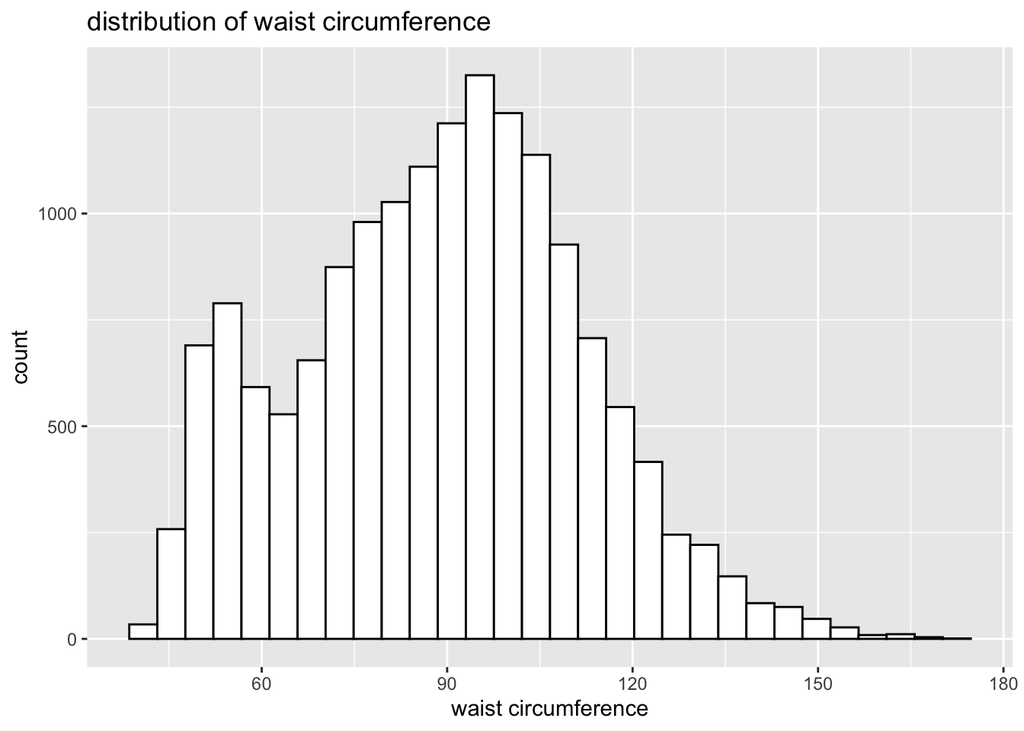

```r
# Add mean line
p+geom_vline(aes(xintercept=mean(BMXWAIST)),
            color="blue", linetype="dashed", size=1)
```

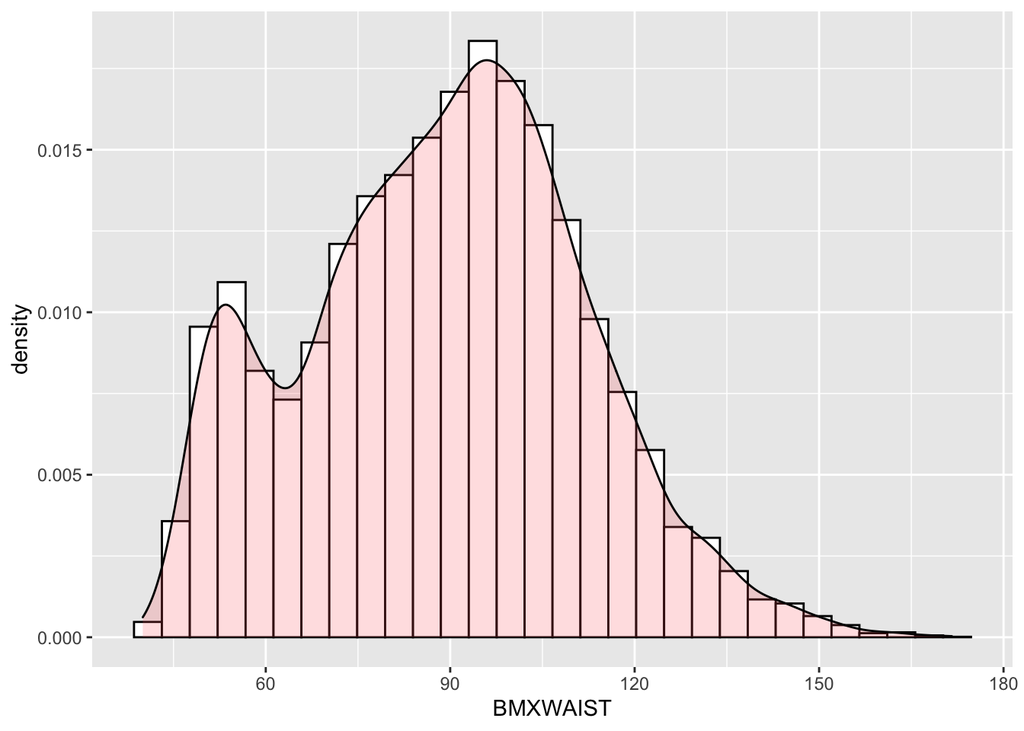

```r
# Histogram with density plot
ggplot(nhanes1518, aes(x=BMXWAIST)) +
 geom_histogram(aes(y=..density..), colour="black", fill="white")+
 geom_density(alpha=.2, fill="#FF6666")
```

## 3. Simple Linear Regression

We’ll start with a fitting a simple linear model using the `lm()` function. Instead of attaching the `nhanes1518` dataset, we also can specify the data from the `lm()` function. In the `lm()` function, the first variable is the response variable and the variables to the right of the `~` symbol are the predictor variable(s).

```r
lm.fit <- lm(BMXBMI ~ BMXWAIST, data = nhanes1518)
```

There are several ways that we can examine the model results. First, we can just call the name of the `lm()` model for a brief summary.

```r
lm.fit
```

```
##
## Call:
## lm(formula = BMXBMI ~ BMXWAIST, data = nhanes1518)
##
## Coefficients:
## (Intercept)     BMXWAIST
##     -2.7494       0.3263
```

We can also use the `names()` function to list all of the names of variables in the `lm.fit` model:

```r
names(lm.fit)
```

```
##  [1] "coefficients"  "residuals"     "effects"       "rank"
##  [5] "fitted.values" "assign"        "qr"            "df.residual"
##  [9] "na.action"     "xlevels"       "call"          "terms"
## [13] "model"
```

The `summary()` function gives a more extensive overview of the model fit:

```r
summary(lm.fit)
```

```
##
## Call:
## lm(formula = BMXBMI ~ BMXWAIST, data = nhanes1518)
##
## Residuals:
##      Min       1Q   Median       3Q      Max
## -11.6223  -1.7801  -0.2015   1.5059  28.0242
##
## Coefficients:
##               Estimate Std. Error t value Pr(>|t|)
## (Intercept) -2.7494044  0.0901361   -30.5   <2e-16 ***
## BMXWAIST     0.3262899  0.0009815   332.4   <2e-16 ***
## ---
## Signif. codes:  0 '***' 0.001 '**' 0.01 '*' 0.05 '.' 0.1 ' ' 1
##
## Residual standard error: 2.822 on 15878 degrees of freedom
##   (3345 observations deleted due to missingness)
## Multiple R-squared:  0.8744, Adjusted R-squared:  0.8744
## F-statistic: 1.105e+05 on 1 and 15878 DF,  p-value: < 2.2e-16
```

The coefficients of the linear regression model can be extracted using the `coef()` function and the confidence interval(s) with the `confint()` function.

```r
coef(lm.fit)
```

```
## (Intercept)    BMXWAIST
##  -2.7494044   0.3262899
```

```r
confint(lm.fit)
```

```
##                 2.5 %     97.5 %
## (Intercept) -2.926081 -2.5727275
## BMXWAIST     0.324366  0.3282138
```

We can use the `predict()` function to obtain prediction intervals or confidence intervals for a given value of the predictor variable, `BMXWAIST`. Note that when using the predict function, the column names and format of the new points at which to predict needs to be the same as the original data frame used to fit the `lm()` model. If you encounter errors using the `predict()` function, this is a good first thing to check.

```r
predict(lm.fit, data.frame(BMXWAIST = (c(70, 80, 90))), interval = "confidence")
```

```
##        fit      lwr      upr
## 1 20.09089 20.03382 20.14795
## 2 23.35379 23.30664 23.40093
## 3 26.61668 26.57275 26.66062
```

```r
predict(lm.fit, data.frame(BMXWAIST = (c(70, 80, 90))), interval = "prediction")
```

```
##        fit      lwr      upr
## 1 20.09089 14.55980 25.62197
## 2 23.35379 17.82279 28.88478
## 3 26.61668 21.08572 32.14765
```

We can plot the variables `BMXBMI` and `BMXWAIST` using the `plot()` function and overlay the regression line found using `lm()` with the `abline()` function.

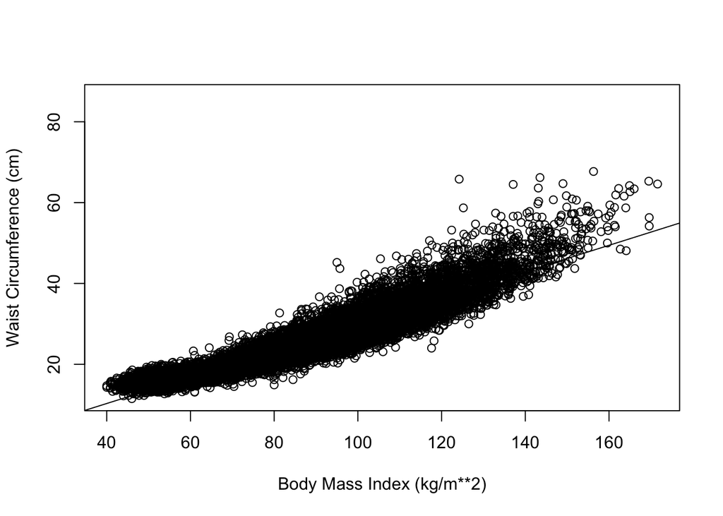

```r
plot(x=nhanes1518$BMXWAIST,y=nhanes1518$BMXBMI, xlab="Body Mass Index (kg/m**2)",ylab="Waist Circumference (cm)")
abline(lm.fit)
```

Here the dollar sign specifies that we retrieve the predictor columns `BMXBMI` and `BMXWAIST` from the dataset `nhanes1518`

We can experiment with different options for `abline()` by changing the line width and color in `abline()`.

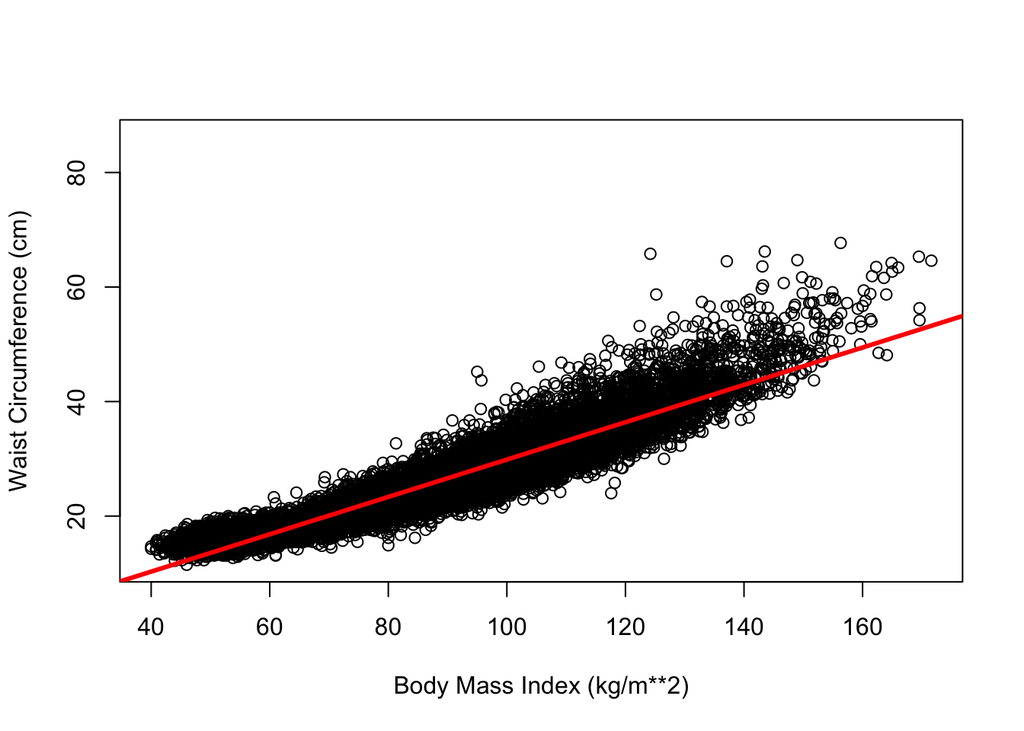

```r
plot(x=nhanes1518$BMXWAIST,y=nhanes1518$BMXBMI, xlab="Body Mass Index (kg/m**2)",ylab="Waist Circumference (cm)")
abline(lm.fit, lwd = 3, col = "red")
```

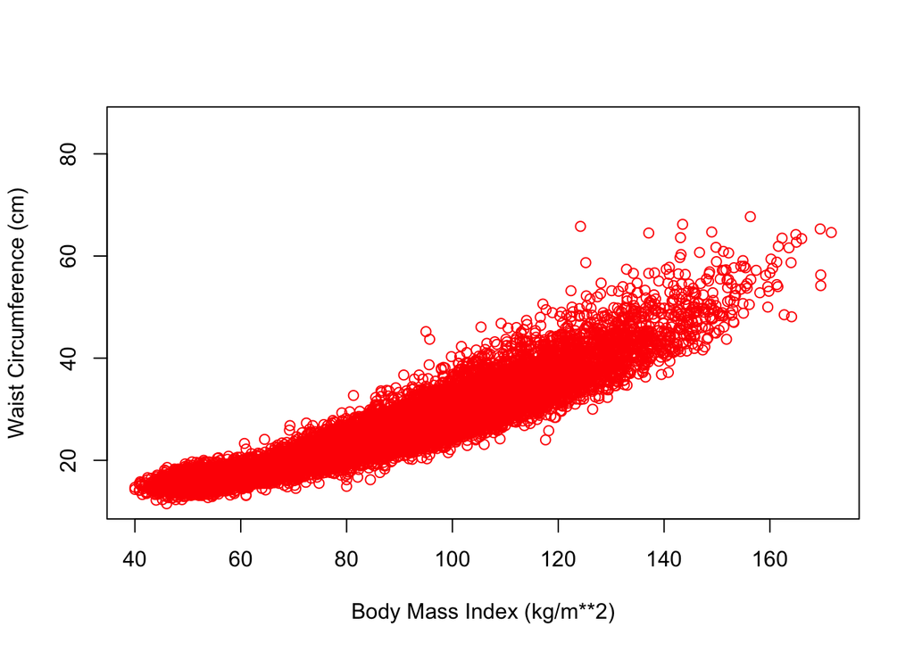

```r
plot(x=nhanes1518$BMXWAIST,y=nhanes1518$BMXBMI, xlab="Body Mass Index (kg/m**2)",ylab="Waist Circumference (cm)", col = "red")
```

The `pch` argument in `plot()` changes the shape/type of the points that are plotted.

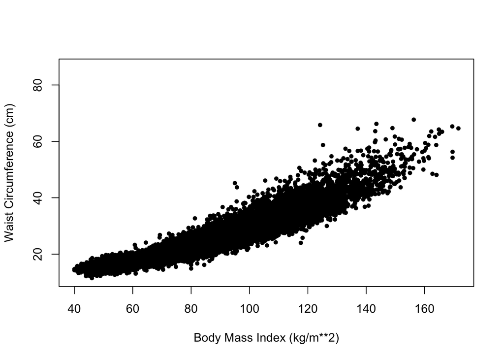

```r
plot(x=nhanes1518$BMXWAIST,y=nhanes1518$BMXBMI, xlab="Body Mass Index (kg/m**2)",ylab="Waist Circumference (cm)",pch = 20)
```

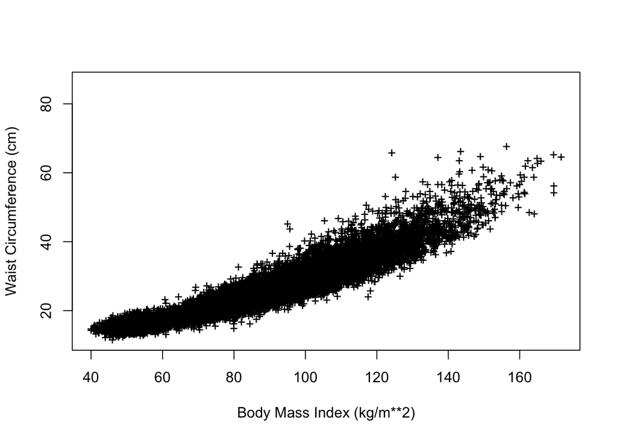

```r
plot(x=nhanes1518$BMXWAIST,y=nhanes1518$BMXBMI, xlab="Body Mass Index (kg/m**2)",ylab="Waist Circumference (cm)",pch = "+")
```

Optional: We can make a similar plot using `ggplot`, where we fit the linear regression model using `ggplot()`.

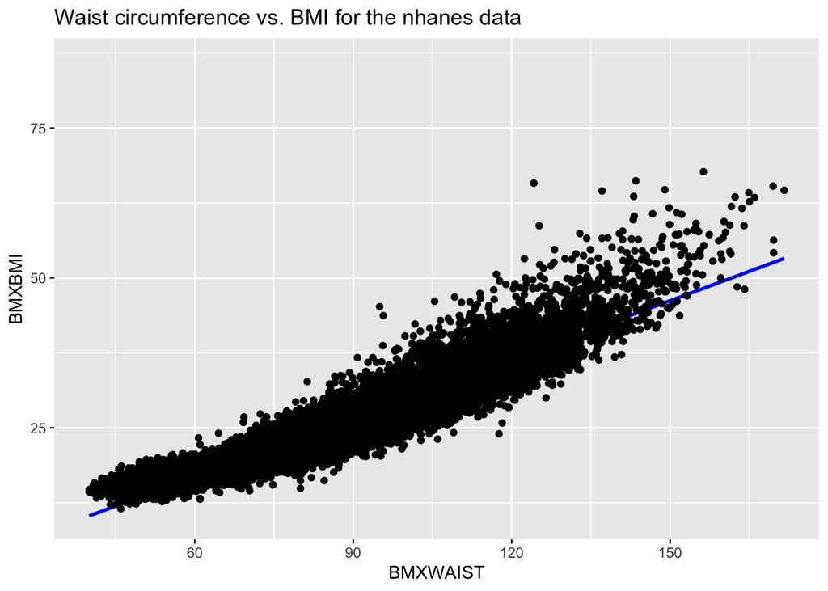

```r
library(ggplot2)
ggplot(nhanes1518, aes(y = BMXBMI, x = BMXWAIST)) +
    geom_smooth(method = "lm", formula = y ~ x, colour = "blue") +
    geom_point() +
  ggtitle("Waist circumference vs. BMI for the nhanes data")
```

We can use the `residuals()` and `rstudent()` functions to extract the residuals and studentized residuals, respectively, from the linear model and plot them along with the predicted values.

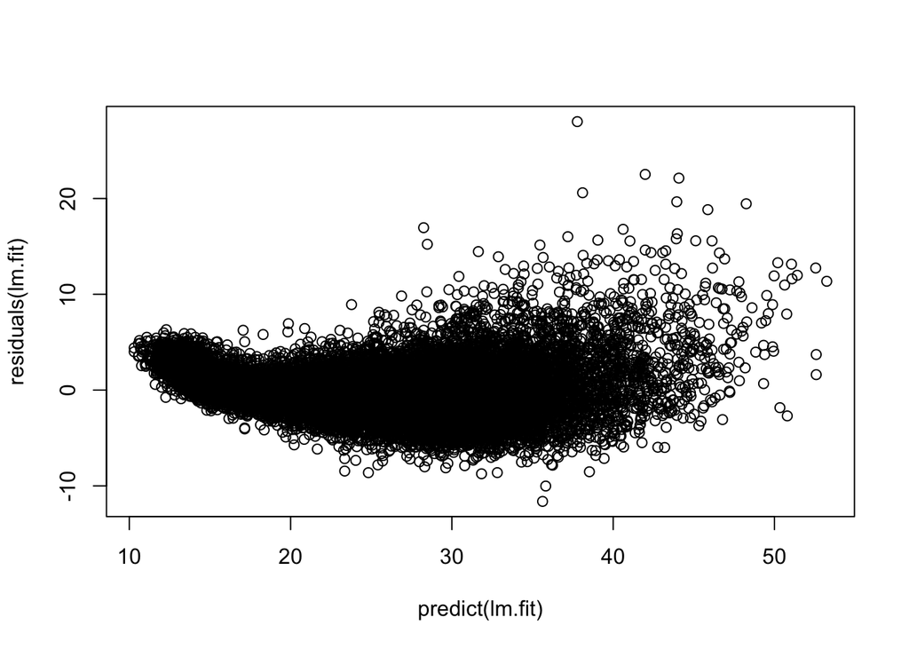

```r
plot(predict(lm.fit), residuals(lm.fit))
```

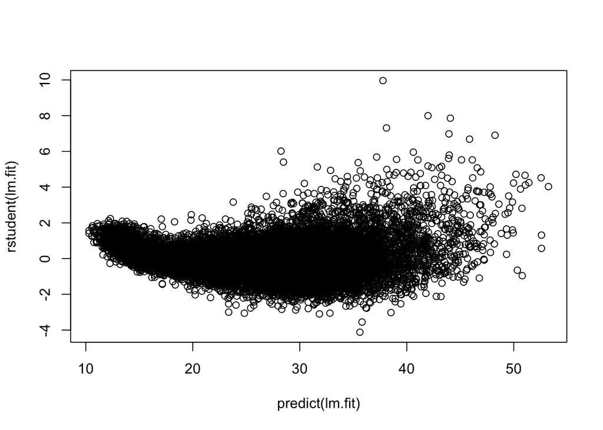

```r
plot(predict(lm.fit), rstudent(lm.fit))
```

Additionally, we can compute the influence matrix for the predictors using the `hatvalues()` function.

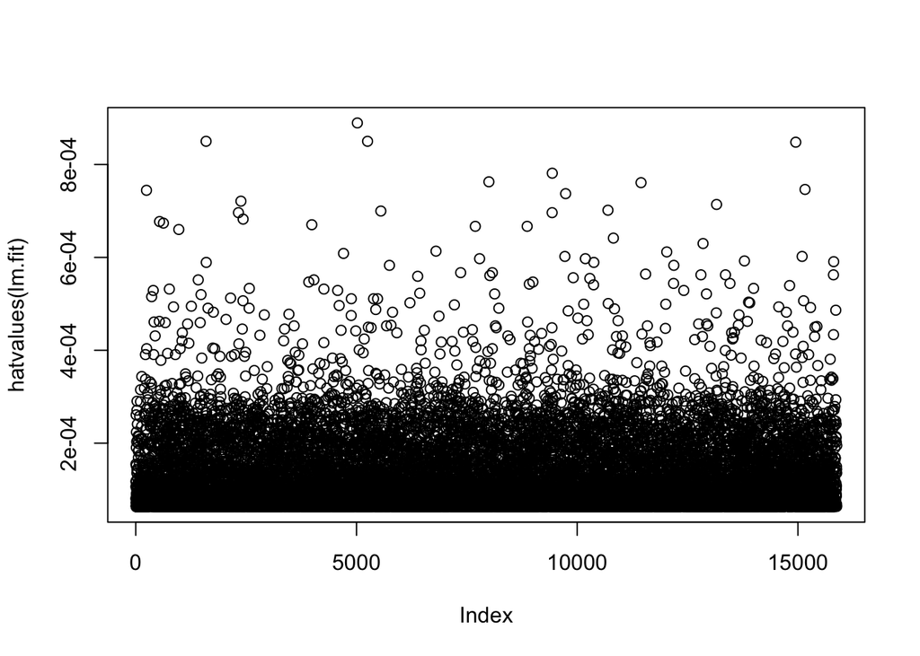

```r
plot(hatvalues(lm.fit))
```

```r
which.max(hatvalues(lm.fit))
```

```
## 6079
## 5020
```

## 4. Model Diagonostics & Interpretation

The `par()` function can be used to create a grid of multiple subplots.

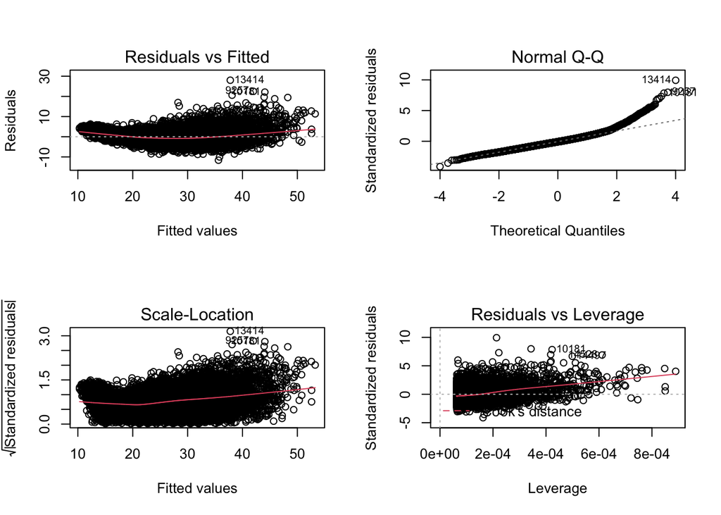

```r
par(mfrow = c(2, 2))
plot(lm.fit)
```

Some other metrics from the model:

- $R^2$: From the model above, we have an adjusted R-squared value of 0.8744, which indicates that 87.44% of the variability in the response variable Body BMI can be explained by the change in the predictor variable waist circumference.
- p value: The p value tells us how likely the data we have observed is to have occurred under the null hypothesis (more material on Null hypothesis on subsequent tutorials), i.e. that there is no correlation between the predictor variable waist circumference and the response BMI. From the model above, we have a p value of 2.2e-16, which tells us that the predictor variable waist circumference is statistically significant.

## 5. Multiple Linear Regression

The `lm()` function can also fit multiple regression models. In this section, we will use `BMXWAIST`, `BMXWT`and`BMXHT`as predictors of the response variable`BMXBMI``.

```r
lm.fit <- lm(BMXBMI ~ BMXWAIST + BMXWT + BMXHT, data = nhanes1518)
summary(lm.fit)
```

```
##
## Call:
## lm(formula = BMXBMI ~ BMXWAIST + BMXWT + BMXHT, data = nhanes1518)
##
## Residuals:
##     Min      1Q  Median      3Q     Max
## -8.7434 -0.9249  0.0837  0.9059 12.4252
##
## Coefficients:
##               Estimate Std. Error t value Pr(>|t|)
## (Intercept) 24.2579387  0.1494711  162.29   <2e-16 ***
## BMXWAIST     0.1317012  0.0017982   73.24   <2e-16 ***
## BMXWT        0.2496303  0.0016215  153.95   <2e-16 ***
## BMXHT       -0.1706749  0.0009301 -183.51   <2e-16 ***
## ---
## Signif. codes:  0 '***' 0.001 '**' 0.01 '*' 0.05 '.' 0.1 ' ' 1
##
## Residual standard error: 1.546 on 15876 degrees of freedom
##   (3345 observations deleted due to missingness)
## Multiple R-squared:  0.9623, Adjusted R-squared:  0.9623
## F-statistic: 1.35e+05 on 3 and 15876 DF,  p-value: < 2.2e-16
```

```r
library(dplyr)
nhanes_na_removed<-cbind(nhanes1518[1:5],nhanes1518$BMXBMI)
# data clearning to ignore NA values
lm.fit1 <- lm(nhanes1518$BMXBMI ~ ., data = nhanes_na_removed)
summary(lm.fit1)
```

```
##
## Call:
## lm(formula = nhanes1518$BMXBMI ~ ., data = nhanes_na_removed)
##
## Residuals:
##        Min         1Q     Median         3Q        Max
## -1.553e-12 -1.700e-16  8.000e-17  3.400e-16  2.057e-14
##
## Coefficients: (1 not defined because of singularities)
##                       Estimate Std. Error    t value Pr(>|t|)
## (Intercept)          3.296e-14  1.615e-15  2.041e+01  < 2e-16 ***
## SEQN                 5.892e-20  1.685e-20  3.497e+00 0.000471 ***
## WTINT2YR             2.010e-19  2.855e-20  7.039e+00 2.01e-12 ***
## WTMEC2YR            -1.496e-19  2.736e-20 -5.466e+00 4.67e-08 ***
## RIDSTATR                    NA         NA         NA       NA
## RIAGENDR             1.430e-15  1.862e-16  7.678e+00 1.71e-14 ***
## `nhanes1518$BMXBMI`  1.000e+00  1.158e-17  8.634e+16  < 2e-16 ***
## ---
## Signif. codes:  0 '***' 0.001 '**' 0.01 '*' 0.05 '.' 0.1 ' ' 1
##
## Residual standard error: 1.201e-14 on 16755 degrees of freedom
##   (2464 observations deleted due to missingness)
## Multiple R-squared:      1,  Adjusted R-squared:      1
## F-statistic: 1.528e+33 on 5 and 16755 DF,  p-value: < 2.2e-16
```

```r
library(dplyr)
nhanes_na_removed<-cbind(nhanes1518[1:5],nhanes1518$BMXBMI)
# data clearning to ignore NA values
lm.fit1 <- lm(nhanes1518$BMXBMI ~ . - RIDSTATR, data = nhanes_na_removed)
summary(lm.fit1)
```

```
##
## Call:
## lm(formula = nhanes1518$BMXBMI ~ . - RIDSTATR, data = nhanes_na_removed)
##
## Residuals:
##        Min         1Q     Median         3Q        Max
## -1.553e-12 -1.700e-16  8.000e-17  3.400e-16  2.057e-14
##
## Coefficients:
##                       Estimate Std. Error    t value Pr(>|t|)
## (Intercept)          3.296e-14  1.615e-15  2.041e+01  < 2e-16 ***
## SEQN                 5.892e-20  1.685e-20  3.497e+00 0.000471 ***
## WTINT2YR             2.010e-19  2.855e-20  7.039e+00 2.01e-12 ***
## WTMEC2YR            -1.496e-19  2.736e-20 -5.466e+00 4.67e-08 ***
## RIAGENDR             1.430e-15  1.862e-16  7.678e+00 1.71e-14 ***
## `nhanes1518$BMXBMI`  1.000e+00  1.158e-17  8.634e+16  < 2e-16 ***
## ---
## Signif. codes:  0 '***' 0.001 '**' 0.01 '*' 0.05 '.' 0.1 ' ' 1
##
## Residual standard error: 1.201e-14 on 16755 degrees of freedom
##   (2464 observations deleted due to missingness)
## Multiple R-squared:      1,  Adjusted R-squared:      1
## F-statistic: 1.528e+33 on 5 and 16755 DF,  p-value: < 2.2e-16
```

Including `-1` excludes the intercept from the model.

```r
lm.fit1 <- lm(nhanes1518$BMXBMI ~ .- 1, data = nhanes_na_removed)
summary(lm.fit1)
```

```
##
## Call:
## lm(formula = nhanes1518$BMXBMI ~ . - 1, data = nhanes_na_removed)
##
## Residuals:
##        Min         1Q     Median         3Q        Max
## -5.840e-14 -7.000e-16 -2.000e-16  2.000e-16  4.267e-12
##
## Coefficients:
##                       Estimate Std. Error    t value Pr(>|t|)
## SEQN                -1.648e-19  4.626e-20 -3.562e+00 0.000369 ***
## WTINT2YR            -5.405e-19  7.839e-20 -6.895e+00 5.57e-12 ***
## WTMEC2YR             4.031e-19  7.513e-20  5.366e+00 8.17e-08 ***
## RIDSTATR            -4.372e-14  2.217e-15 -1.972e+01  < 2e-16 ***
## RIAGENDR            -3.739e-15  5.113e-16 -7.313e+00 2.73e-13 ***
## `nhanes1518$BMXBMI`  1.000e+00  3.180e-17  3.144e+16  < 2e-16 ***
## ---
## Signif. codes:  0 '***' 0.001 '**' 0.01 '*' 0.05 '.' 0.1 ' ' 1
##
## Residual standard error: 3.298e-14 on 16755 degrees of freedom
##   (2464 observations deleted due to missingness)
## Multiple R-squared:      1,  Adjusted R-squared:      1
## F-statistic: 1.943e+33 on 6 and 16755 DF,  p-value: < 2.2e-16
```

The `update()` function can be used to specify a new formula for an existing model.

```r
lm.fit1 <- update(lm.fit, ~. - RIDSTATR)
```

## 6. Interaction Terms

There are two ways to include interaction terms in the model, `:` and `*`. The `:` symbol only includes the interaction term between the two variables, while the `*` symbol includes the variables themselves, as well as the interaction terms. This means that `BMXWT*BMXWAIST` is equivalent to `BMXWT + BMXWAIST + BMXWT:BMXWAIST`.

```r
summary(lm(BMXBMI ~  BMXWT* BMXWAIST, data = nhanes1518))
```

```
##
## Call:
## lm(formula = BMXBMI ~ BMXWT * BMXWAIST, data = nhanes1518)
##
## Residuals:
##      Min       1Q   Median       3Q      Max
## -12.8956  -1.5338  -0.1822   1.3309  21.1604
##
## Coefficients:
##                  Estimate Std. Error t value Pr(>|t|)
## (Intercept)     7.3875398  0.1671610   44.19   <2e-16 ***
## BMXWT          -0.0488326  0.0029835  -16.37   <2e-16 ***
## BMXWAIST        0.1515807  0.0030645   49.46   <2e-16 ***
## BMXWT:BMXWAIST  0.0013039  0.0000221   59.00   <2e-16 ***
## ---
## Signif. codes:  0 '***' 0.001 '**' 0.01 '*' 0.05 '.' 0.1 ' ' 1
##
## Residual standard error: 2.474 on 15876 degrees of freedom
##   (3345 observations deleted due to missingness)
## Multiple R-squared:  0.9034, Adjusted R-squared:  0.9034
## F-statistic: 4.951e+04 on 3 and 15876 DF,  p-value: < 2.2e-16
```

A simple way to include all interaction terms is the syntax `.^2`.

```r
library(dplyr)
nhanes_na_removed<-cbind(nhanes1518[1:5],nhanes1518$BMXBMI)
# data clearning to ignore NA values
summary(lm(nhanes1518$BMXBMI ~ .^2, data = nhanes_na_removed))
```

```
##
## Call:
## lm(formula = nhanes1518$BMXBMI ~ .^2, data = nhanes_na_removed)
##
## Residuals:
##        Min         1Q     Median         3Q        Max
## -1.552e-12 -2.100e-16  4.000e-17  3.900e-16  2.037e-14
##
## Coefficients: (6 not defined because of singularities)
##                                Estimate Std. Error    t value Pr(>|t|)
## (Intercept)                   4.070e-14  7.102e-15  5.731e+00 1.01e-08 ***
## SEQN                         -3.233e-20  7.567e-20 -4.270e-01   0.6692
## WTINT2YR                     -5.946e-20  5.504e-19 -1.080e-01   0.9140
## WTMEC2YR                      1.456e-19  5.300e-19  2.750e-01   0.7836
## RIDSTATR                             NA         NA         NA       NA
## RIAGENDR                     -3.849e-15  3.201e-15 -1.203e+00   0.2292
## `nhanes1518$BMXBMI`           1.000e+00  2.012e-16  4.971e+15  < 2e-16 ***
## SEQN:WTINT2YR                 2.686e-24  5.636e-24  4.770e-01   0.6337
## SEQN:WTMEC2YR                -3.142e-24  5.428e-24 -5.790e-01   0.5627
## SEQN:RIDSTATR                        NA         NA         NA       NA
## SEQN:RIAGENDR                 5.655e-20  3.385e-20  1.671e+00   0.0948 .
## SEQN:`nhanes1518$BMXBMI`      1.016e-21  2.116e-21  4.800e-01   0.6311
## WTINT2YR:WTMEC2YR            -7.478e-27  2.775e-26 -2.690e-01   0.7876
## WTINT2YR:RIDSTATR                    NA         NA         NA       NA
## WTINT2YR:RIAGENDR            -1.275e-20  5.808e-20 -2.200e-01   0.8262
## WTINT2YR:`nhanes1518$BMXBMI` -4.570e-22  4.253e-21 -1.070e-01   0.9144
## WTMEC2YR:RIDSTATR                    NA         NA         NA       NA
## WTMEC2YR:RIAGENDR             1.522e-20  5.576e-20  2.730e-01   0.7849
## WTMEC2YR:`nhanes1518$BMXBMI`  4.801e-22  4.104e-21  1.170e-01   0.9069
## RIDSTATR:RIAGENDR                    NA         NA         NA       NA
## RIDSTATR:`nhanes1518$BMXBMI`         NA         NA         NA       NA
## RIAGENDR:`nhanes1518$BMXBMI` -7.478e-18  2.358e-17 -3.170e-01   0.7511
## ---
## Signif. codes:  0 '***' 0.001 '**' 0.01 '*' 0.05 '.' 0.1 ' ' 1
##
## Residual standard error: 1.201e-14 on 16745 degrees of freedom
##   (2464 observations deleted due to missingness)
## Multiple R-squared:      1,  Adjusted R-squared:      1
## F-statistic: 5.094e+32 on 15 and 16745 DF,  p-value: < 2.2e-16
```

## 7. Categorical Variable

```r
nhanes_na_removed<-cbind(nhanes1518[1:5],nhanes1518$BMXBMI, nhanes1518$INDHHIN2)
nhanes_income <- dplyr::rename(nhanes_na_removed,income = "nhanes1518$INDHHIN2")%>% na.omit()
nhanes_income <- dplyr::rename(nhanes_income,BMI = "nhanes1518$BMXBMI")
# turn quantitative variable into categorical variable
nhanes_income$income<-as.character(nhanes_income$income)
```

Now we explore the effect of income as a categorical predictor variable on the response BMI. Refer to the website for encoding of income categories:

https://wwwn.cdc.gov/nchs/nhanes/2011-2012/demo_g.htm#INDHHIN2

```r
summary(lm(BMI ~ income, data = nhanes_income))
```

```
##
## Call:
## lm(formula = BMI ~ income, data = nhanes_income)
##
## Residuals:
##     Min      1Q  Median      3Q     Max
## -14.513  -6.201  -0.724   4.654  59.658
##
## Coefficients:
##             Estimate Std. Error t value Pr(>|t|)
## (Intercept)  25.6489     0.3831  66.952  < 2e-16 ***
## income10      0.3345     0.4762   0.702  0.48244
## income12      0.8877     0.5179   1.714  0.08654 .
## income13      1.4388     0.6596   2.181  0.02918 *
## income14      0.3518     0.4350   0.809  0.41867
## income15     -0.5433     0.4116  -1.320  0.18688
## income2       1.1033     0.5164   2.137  0.03264 *
## income3       1.2712     0.4765   2.668  0.00764 **
## income4       0.7567     0.4609   1.642  0.10062
## income5       0.6756     0.4594   1.471  0.14144
## income6       1.1473     0.4291   2.674  0.00750 **
## income7       1.0645     0.4325   2.461  0.01385 *
## income77      1.0735     0.5875   1.827  0.06765 .
## income8       1.0973     0.4471   2.454  0.01413 *
## income9       0.8931     0.4563   1.957  0.05034 .
## income99      1.2584     0.6035   2.085  0.03707 *
## ---
## Signif. codes:  0 '***' 0.001 '**' 0.01 '*' 0.05 '.' 0.1 ' ' 1
##
## Residual standard error: 8.09 on 16125 degrees of freedom
## Multiple R-squared:  0.005932,   Adjusted R-squared:  0.005007
## F-statistic: 6.415 on 15 and 16125 DF,  p-value: 7.53e-14
```

*Baseline*: income 1 corresponding to a household income of 0 to 4,999 dollars.

*Model Interpretation*: `income6`: The coeffcient for the predictor 1.1473 means that for participants with household income category 6 (25,000 to 34,999 dollars per ear), the BMI is expected to be 1.1473 higher than that of participants with household income in category 1 (0 to 4,999 dollars), on average.

## Related Topics

| **Topics** | **Concepts** |
| --- | --- |
| ANOVA | Null hypothesis |
| Quantile factoring | use qualitative as levels |
| Cross-validation | k-fold, LOOCV |
| Model section | AIC, BIC, Cp |